# Kétmintás próbák

## Alapfogalmak és kérdések

- Mi a statisztikai hipotézis?
- Milyen a jó hipotézis?
- Mire vonatkozik a hipotézis?
- Milyen paraméterekre, jellemzőkre vonatkozhat?
- Minek végzünk hipotézisvizsgálatot?
- Mi a nullhipotézis / ellenhipotézis? Milyen ezek viszonya?
- Mi az első / másodfajú hiba?
- Mi a nulleloszlás?
- Mit jelent, hogy egy próba szignifikáns?

## Kétmintás próbák a várható értékre

## Kétmintás (független mintás) próbák

- Két **független** populációban vizsgáljuk
- egy változó **várható értékének különbségét**
- Két populáció, független változó: nominális
- Függő változó: intervallum- vagy arányskála
- Mintában különbözik a várható érték két csoportban
- Állítható-e, hogy ezek **a populációban sem egyenlők?**

\[H_0: \mu_1 = \mu_2\] \[H_1: \mu_1 \ne \mu_2\] vagy: \(< / >\)

## A választék

- Mindhárom esetben feltétel a normális eloszlás - tesztelendő
1. Kétmintás u-próba: ismert populációs szórásokkal
2. Kétmintás t-próba: ha a becsült szórások alapján a populációban szóráshomogenitás van
3. Kétmintás Welch-próba: ha nem feltételezhető a szóráshomogenitás
- Utóbbi két esetben a szóráshomogenitást tesztelni kell: F-próba
- Robusztusság vs. próba ereje

\[u > t > t_w\]

## Kétmintás u-próba

- ismert valódi szórású
- normális eloszlású változókkal

\[u = \frac{\overline{X}-\overline{Y}}{\sqrt{\frac{\sigma_x^2}{N_x}+\frac{\sigma_y^2}{N_y}}}\]

Nulleloszlása: N(0;1)

## Kétmintás u-próba nulleloszlása

\(\mu_x = 200; \quad \mu_y = 200; \quad \sigma_x = 50; \quad \sigma_y = 40; \quad N_x=100; \quad N_y=120\)

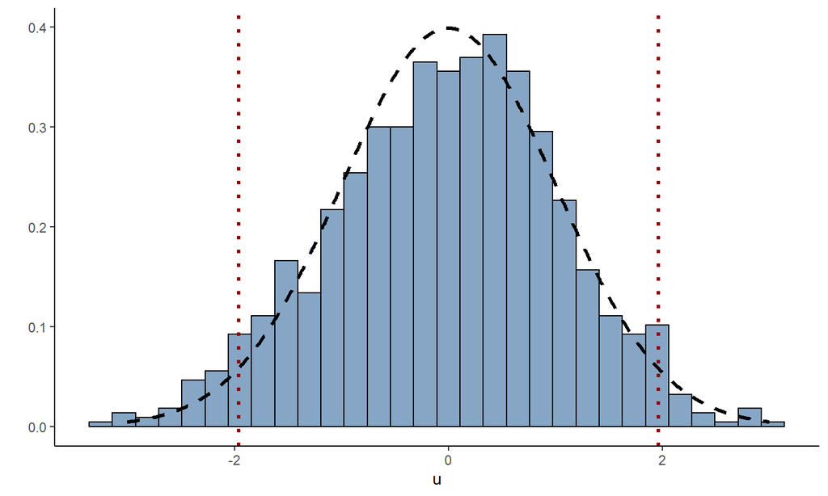

## Ha a nullhipotézis nem igaz

\(\mu_x = 200; \quad \mu_y = 220; \quad \sigma_x = 50; \quad \sigma_y = 40; \quad N_x=100; \quad N_y=120\)

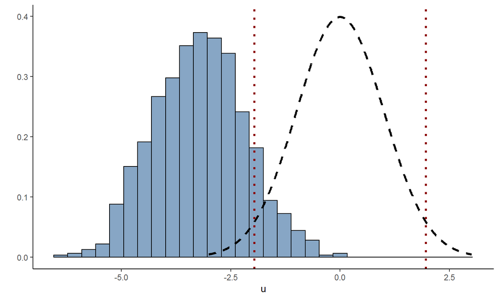

## Példa

A bergengóc férfiak almintája 30 fős, az átlagos jövedelem 400 fabatka; a női alminta 20 fős, az átlagos jövedelem 370 fabatka. Tegyük fel, hogy ismerjük a jövedelem szórását a bergengóc férfi és női populációban: a férfiak körében 50, a nők körében 45 a szórás. Állítható-e, hogy a bergengóc férfiak és nők várható jövedelme különbözik?

## Példa

A bergengóc férfiak almintája 30 fős, az átlagos jövedelem 400 fabatka; a női alminta 20 fős, az átlagos jövedelem 370 fabatka. Tegyük fel, hogy ismerjük a jövedelem szórását a bergengóc férfi és női **populációban**: a férfiak körében 50, a nők körében 45 a szórás. Állítható-e, hogy a bergengóc férfiak és nők várható jövedelme különbözik?

## Példa megoldása

\(\overline{X}=400;\quad \overline{Y}=370;\quad \sigma_x=50;\quad \sigma_y=45;\quad N_x=30;\quad N_y=20\)

\[H_0: \mu_x = \mu_y\] \[H_1: \mu_x \ne \mu_y\]

\[u = \frac{400-370}{\sqrt{\frac{50^2}{30}+\frac{45^2}{20}}}=2.21\] \[\pm z_{0.975}=\pm 1,96\] A különbség 5% szignifikanciaszint mellett szignifikáns.

SPSS: 0.027

## Becsült szórásokkal

## Szóráshomogenitás: F-próba

\[H_0: \sigma_x = \sigma_y\] \[H_1: \sigma_x \ne \sigma_y\]

\[F=\frac{s_x^{\ast 2}}{s_y^{\ast 2}}\]

Nulleloszlása: \(F(N_x-1;N_y-1)\)  
Hivatalos határérték: \(\quad F_{0,975; N_x-1; N_y-1}; \quad \frac{1}{F_{0,975;N_y-1;N_x-1}}\)

Mi határértékünk: \(\quad F_{0,95; N_x-1; N_y-1}\)  
Trükk: nagyobb szórás a számlálóba

## F-eloszlás

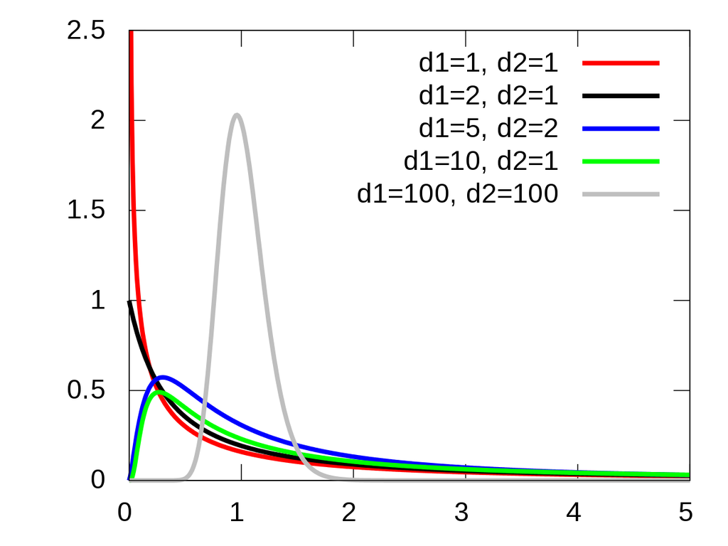

## Ha a nullhipotézis igaz

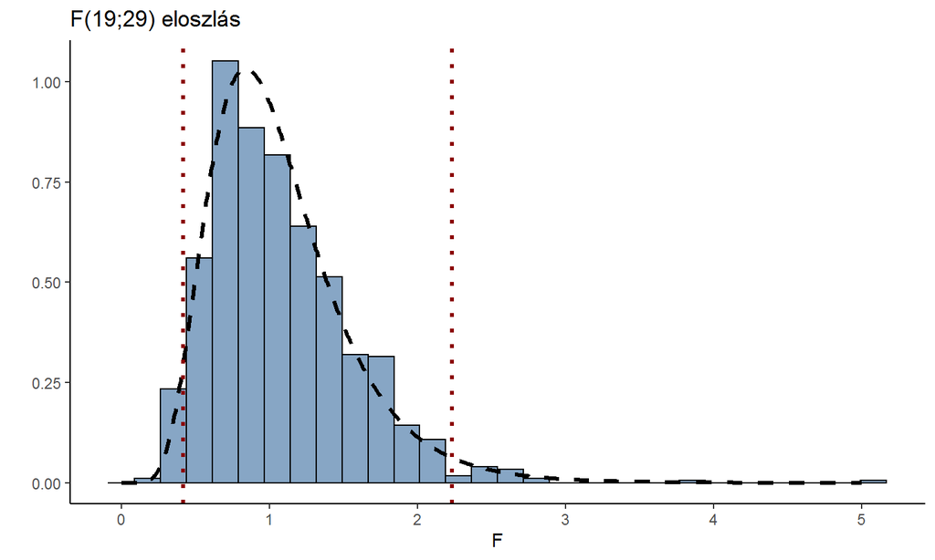

## t-próba / Welch-próba

\[H_0: \mu_x = \mu_y \qquad H_1: \mu_x \ne \mu_y\]

Szóráshomogenitás esetén:

\[t = \frac{\overline{X}-\overline{Y}}{\sqrt{s_k^{\ast 2}*\left(\frac{1}{N_x}+\frac{1}{N_y}\right)}}\] \[s_k^{\ast 2}=\frac{(N_x-1)*s_x^{\ast 2}+(N_y-1)*s_y^{\ast 2}}{N_x+N_y-2}\] Nulleloszlás: \(t(N_x+N_y-2)\)

Ha nincs szóráshomogenitás:

\[t_w = \frac{\overline{X}-\overline{Y}}{\sqrt{\frac{s_x^{\ast 2}}{N_x}+\frac{s_y^{\ast 2}}{N_y}}}\] Nulleloszlás: \(t(df)\)  
\[df = \frac{(a+b)^2}{\frac{a^2}{N_x-1}+\frac{b^2}{N_y-1}}\] \[a = \frac{s_x^{\ast 2}}{N_x}; \quad b = \frac{s_y^{\ast 2}}{N_y}\]

## Feladatok

- \(\overline{X}=400; \quad \overline{Y}=370; \quad s_x^{\ast}=49; \quad s_y^{\ast}=43; \quad N_x=31; \quad N_y=20\)
- \(\overline{X}=185; \quad \overline{Y}=170; \quad s_x^{\ast}=5; \quad s_y^{\ast}=8; \quad N_x=41; \quad N_y=31\)
- \(\overline{X}=27; \quad \overline{Y}=25; \quad s_x^{\ast}=4; \quad s_y^{\ast}=3; \quad N_x=10; \quad N_y=15\)
- \(\overline{X}=19; \quad \overline{Y}=27; \quad s_x^{\ast}=5; \quad s_y^{\ast}=7; \quad N_x=41; \quad N_y=61\)

## 1. feladat

\(\overline{X}=400; \quad \overline{Y}=370; \quad s_x^{\ast}=49; \quad s_y^{\ast}=43; \quad N_x=31; \quad N_y=20\)

## 1. feladat

\(\overline{X}=400; \quad \overline{Y}=370; \quad s_x^{\ast}=49; \quad s_y^{\ast}=43; \quad N_x=31; \quad N_y=20\)

\[H_0: \sigma_x = \sigma_y\] \[H_1: \sigma_x \ne \sigma_y\]

## 1. feladat

\(\overline{X}=400; \quad \overline{Y}=370; \quad s_x^{\ast}=49; \quad s_y^{\ast}=43; \quad N_x=31; \quad N_y=20\)

\[H_0: \sigma_x = \sigma_y\] \[H_1: \sigma_x \ne \sigma_y\]

\[F=\frac{49^2}{43^2}=1.30\]

## 1. feladat

\(\overline{X}=400; \quad \overline{Y}=370; \quad s_x^{\ast}=49; \quad s_y^{\ast}=43; \quad N_x=31; \quad N_y=20\)

\[H_0: \sigma_x = \sigma_y\] \[H_1: \sigma_x \ne \sigma_y\]

\[F=\frac{49^2}{43^2}=1.30\] \[F_{0,95;30;19} = 2.07\]

## 1. feladat

\(\overline{X}=400; \quad \overline{Y}=370; \quad s_x^{\ast}=49; \quad s_y^{\ast}=43; \quad N_x=31; \quad N_y=20\)

\[H_0: \sigma_x = \sigma_y\] \[H_1: \sigma_x \ne \sigma_y\]

\[F=\frac{49^2}{43^2}=1.30\] \[F_{0,95;30;19} = 2.07\] A különbség \(\alpha = 0.05\) szignifikanciaszint mellett nem szignifikáns, ezért t-próbát használunk

## 1. feladat

\(\overline{X}=400; \quad \overline{Y}=370; \quad s_x^{\ast}=49; \quad s_y^{\ast}=43; \quad N_x=31; \quad N_y=20\)

\[H_0: \sigma_x = \sigma_y\] \[H_1: \sigma_x \ne \sigma_y\]

\[F=\frac{49^2}{43^2}=1.30\] \[F_{0,95;30;19} = 2.07\] A különbség \(\alpha = 0.05\) szignifikanciaszint mellett nem szignifikáns, ezért t-próbát használunk

SPSS: p = 0.278

## 1. feladat

\(\overline{X}=400; \quad \overline{Y}=370; \quad s_x^{\ast}=49; \quad s_y^{\ast}=43; \quad N_x=31; \quad N_y=20\)

\[H_0: \mu_x = \mu_y\] \[H_1: \mu_x \ne \mu_y\]

## 1. feladat

\(\overline{X}=400; \quad \overline{Y}=370; \quad s_x^{\ast}=49; \quad s_y^{\ast}=43; \quad N_x=31; \quad N_y=20\)

\[s_k^{\ast 2} = \frac{(31-1)*49^2+(20-1)*43^2}{31+20-2}=2186.96\]

## 1. feladat

\(\overline{X}=400; \quad \overline{Y}=370; \quad s_x^{\ast}=49; \quad s_y^{\ast}=43; \quad N_x=31; \quad N_y=20\)

\[s_k^{\ast 2} = \frac{(31-1)*49^2+(20-1)*43^2}{31+20-2}=2186.96\] \[t = \frac{400-370}{\sqrt{2186.96 * \left(\frac{1}{31}+\frac{1}{20}\right)}}=2.24\]

## 1. feladat

\(\overline{X}=400; \quad \overline{Y}=370; \quad s_x^{\ast}=49; \quad s_y^{\ast}=43; \quad N_x=31; \quad N_y=20\)

\[s_k^{\ast 2} = \frac{(31-1)*49^2+(20-1)*43^2}{31+20-2}=2186.96\] \[t = \frac{400-370}{\sqrt{2186.96 * \left(\frac{1}{31}+\frac{1}{20}\right)}}=2.24\] \[df = 31+20-2=49\]

## 1. feladat

\(\overline{X}=400; \quad \overline{Y}=370; \quad s_x^{\ast}=49; \quad s_y^{\ast}=43; \quad N_x=31; \quad N_y=20\)

\[s_k^{\ast 2} = \frac{(31-1)*49^2+(20-1)*43^2}{31+20-2}=2186.96\] \[t = \frac{400-370}{\sqrt{2186.96 * \left(\frac{1}{31}+\frac{1}{20}\right)}}=2.24\] \[df = 31+20-2=49\] \[\pm t_{0,975;40}= \pm 2.02\]

## 1. feladat

\(\overline{X}=400; \quad \overline{Y}=370; \quad s_x^{\ast}=49; \quad s_y^{\ast}=43; \quad N_x=31; \quad N_y=20\)

\[s_k^{\ast 2} = \frac{(31-1)*49^2+(20-1)*43^2}{31+20-2}=2186.96\] \[t = \frac{400-370}{\sqrt{2186.96 * \left(\frac{1}{31}+\frac{1}{20}\right)}}=2.24\] \[df = 31+20-2=49\] \[\pm t_{0,975;40}= \pm 2.02\] A különbség \(\alpha = 0.05\) szignifikanciaszint mellett szignifikáns.

## 1. feladat

\(\overline{X}=400; \quad \overline{Y}=370; \quad s_x^{\ast}=49; \quad s_y^{\ast}=43; \quad N_x=31; \quad N_y=20\)

\[s_k^{\ast 2} = \frac{(31-1)*49^2+(20-1)*43^2}{31+20-2}=2186.96\] \[t = \frac{400-370}{\sqrt{2186.96 * \left(\frac{1}{31}+\frac{1}{20}\right)}}=2.24\] \[df = 31+20-2=49\] \[\pm t_{0,975;40}= \pm 2.02\] A különbség \(\alpha = 0.05\) szignifikanciaszint mellett szignifikáns. SPSS: p = 0.015

## 2. feladat

\(\overline{X}=185; \quad \overline{Y}=170; \quad s_x^{\ast}=5; \quad s_y^{\ast}=8; \quad N_x=41; \quad N_y=31\)

## 2. feladat

\(\overline{X}=185; \quad \overline{Y}=170; \quad s_x^{\ast}=5; \quad s_y^{\ast}=8; \quad N_x=41; \quad N_y=31\)

\[H_0: \sigma_x = \sigma_y\] \[H_1: \sigma_x \ne \sigma_y\]

## 2. feladat

\(\overline{X}=185; \quad \overline{Y}=170; \quad s_x^{\ast}=5; \quad s_y^{\ast}=8; \quad N_x=41; \quad N_y=31\)

\[H_0: \sigma_x = \sigma_y\] \[H_1: \sigma_x \ne \sigma_y\]

\[F=\frac{8^2}{5^2}=2.56\]

## 2. feladat

\(\overline{X}=185; \quad \overline{Y}=170; \quad s_x^{\ast}=5; \quad s_y^{\ast}=8; \quad N_x=41; \quad N_y=31\)

\[H_0: \sigma_x = \sigma_y\] \[H_1: \sigma_x \ne \sigma_y\]

\[F=\frac{8^2}{5^2}=2.56\] \[F_{0,95;30;40} = 1.74\]

## 2. feladat

\(\overline{X}=185; \quad \overline{Y}=170; \quad s_x^{\ast}=5; \quad s_y^{\ast}=8; \quad N_x=41; \quad N_y=31\)

\[H_0: \sigma_x = \sigma_y\] \[H_1: \sigma_x \ne \sigma_y\]

\[F=\frac{8^2}{5^2}=2.56\] \[F_{0,95;30;40} = 1.74\] A különbség \(\alpha = 0.05\) szignifikanciaszint mellett szignifikáns, ezért Welch-próbát használunk

## 2. feladat

\(\overline{X}=185; \quad \overline{Y}=170; \quad s_x^{\ast}=5; \quad s_y^{\ast}=8; \quad N_x=41; \quad N_y=31\)

\[H_0: \sigma_x = \sigma_y\] \[H_1: \sigma_x \ne \sigma_y\]

\[F=\frac{8^2}{5^2}=2.56\] \[F_{0,95;30;40} = 1.74\] A különbség \(\alpha = 0.05\) szignifikanciaszint mellett szignifikáns, ezért Welch-próbát használunk

SPSS: p = 0.003

## 2. feladat

\(\overline{X}=185; \quad \overline{Y}=170; \quad s_x^{\ast}=5; \quad s_y^{\ast}=8; \quad N_x=41; \quad N_y=31\)

\[H_0: \mu_x = \mu_y\] \[H_1: \mu_x \ne \mu_y\]

## 2. feladat

\(\overline{X}=185; \quad \overline{Y}=170; \quad s_x^{\ast}=5; \quad s_y^{\ast}=8; \quad N_x=41; \quad N_y=31\)

## 2. feladat

\(\overline{X}=185; \quad \overline{Y}=170; \quad s_x^{\ast}=5; \quad s_y^{\ast}=8; \quad N_x=41; \quad N_y=31\)

\[t_w = \frac{185-170}{\sqrt{\frac{5^2}{41}+\frac{8^2}{31}}}=9.17\]

## 2. feladat

\(\overline{X}=185; \quad \overline{Y}=170; \quad s_x^{\ast}=5; \quad s_y^{\ast}=8; \quad N_x=41; \quad N_y=31\)

\[t_w = \frac{185-170}{\sqrt{\frac{5^2}{41}+\frac{8^2}{31}}}=9.17\] \[a = \frac{5^2}{41}=0.61; \quad b = \frac{8^2}{31}=2.06\] \[df = \frac{(0.61+2.06)^2}{\frac{0.61^2}{41-1}+\frac{2.06^2}{31-1}}=47.29\]

## 2. feladat

\(\overline{X}=185; \quad \overline{Y}=170; \quad s_x^{\ast}=5; \quad s_y^{\ast}=8; \quad N_x=41; \quad N_y=31\)

\[t_w = \frac{185-170}{\sqrt{\frac{5^2}{41}+\frac{8^2}{31}}}=9.17\] \[a = \frac{5^2}{41}=0.61; \quad b = \frac{8^2}{31}=2.06\] \[df = \frac{(0.61+2.06)^2}{\frac{0.61^2}{41-1}+\frac{2.06^2}{31-1}}=47.29\] \[\pm t_{0,975;40}= \pm 2.02\]

## 2. feladat

\(\overline{X}=185; \quad \overline{Y}=170; \quad s_x^{\ast}=5; \quad s_y^{\ast}=8; \quad N_x=41; \quad N_y=31\)

\[t_w = \frac{185-170}{\sqrt{\frac{5^2}{41}+\frac{8^2}{31}}}=9.17\] \[a = \frac{5^2}{41}=0.61; \quad b = \frac{8^2}{31}=2.06\] \[df = \frac{(0.61+2.06)^2}{\frac{0.61^2}{41-1}+\frac{2.06^2}{31-1}}=47.29\] \[\pm t_{0,975;40}= \pm 2.02\] A különbség \(\alpha = 0.05\) szignifikanciaszint mellett szignifikáns.

## 2. feladat

\(\overline{X}=185; \quad \overline{Y}=170; \quad s_x^{\ast}=5; \quad s_y^{\ast}=8; \quad N_x=41; \quad N_y=31\)

\[t_w = \frac{185-170}{\sqrt{\frac{5^2}{41}+\frac{8^2}{31}}}=9.17\] \[a = \frac{5^2}{41}=0.61; \quad b = \frac{8^2}{31}=2.06\] \[df = \frac{(0.61+2.06)^2}{\frac{0.61^2}{41-1}+\frac{2.06^2}{31-1}}=47.29\] \[\pm t_{0,975;40}= \pm 2.02\] A különbség \(\alpha = 0.05\) szignifikanciaszint mellett szignifikáns. SPSS: p = 0.000

## 3. feladat

\(\overline{X}=27; \quad \overline{Y}=25; \quad s_x^{\ast}=4; \quad s_y^{\ast}=3; \quad N_x=10; \quad N_y=15\)

## 3. feladat

\(\overline{X}=27; \quad \overline{Y}=25; \quad s_x^{\ast}=4; \quad s_y^{\ast}=3; \quad N_x=10; \quad N_y=15\)

\[H_0: \sigma_x = \sigma_y\] \[H_1: \sigma_x \ne \sigma_y\]

## 3. feladat

\(\overline{X}=27; \quad \overline{Y}=25; \quad s_x^{\ast}=4; \quad s_y^{\ast}=3; \quad N_x=10; \quad N_y=15\)

\[H_0: \sigma_x = \sigma_y\] \[H_1: \sigma_x \ne \sigma_y\]

\[F=\frac{4^2}{3^2}=1.78\]

## 3. feladat

\(\overline{X}=27; \quad \overline{Y}=25; \quad s_x^{\ast}=4; \quad s_y^{\ast}=3; \quad N_x=10; \quad N_y=15\)

\[H_0: \sigma_x = \sigma_y\] \[H_1: \sigma_x \ne \sigma_y\]

\[F=\frac{4^2}{3^2}=1.78\] \[F_{0,95;9;14} = 2.65\]

## 3. feladat

\(\overline{X}=27; \quad \overline{Y}=25; \quad s_x^{\ast}=4; \quad s_y^{\ast}=3; \quad N_x=10; \quad N_y=15\)

\[H_0: \sigma_x = \sigma_y\] \[H_1: \sigma_x \ne \sigma_y\]

\[F=\frac{4^2}{3^2}=1.78\] \[F_{0,95;9;14} = 2.65\] A különbség \(\alpha = 0.05\) szignifikanciaszint mellett nem szignifikáns, ezért t-próbát használunk

## 3. feladat

\(\overline{X}=27; \quad \overline{Y}=25; \quad s_x^{\ast}=4; \quad s_y^{\ast}=3; \quad N_x=10; \quad N_y=15\)

\[H_0: \sigma_x = \sigma_y\] \[H_1: \sigma_x \ne \sigma_y\]

\[F=\frac{4^2}{3^2}=1.78\] \[F_{0,95;9;14} = 2.65\] A különbség \(\alpha = 0.05\) szignifikanciaszint mellett nem szignifikáns, ezért t-próbát használunk

SPSS: p = 0.161

## 3. feladat

\(\overline{X}=27; \quad \overline{Y}=25; \quad s_x^{\ast}=4; \quad s_y^{\ast}=3; \quad N_x=10; \quad N_y=15\)

\[H_0: \mu_x = \mu_y\] \[H_1: \mu_x \ne \mu_y\]

## 3. feladat

\(\overline{X}=27; \quad \overline{Y}=25; \quad s_x^{\ast}=4; \quad s_y^{\ast}=3; \quad N_x=10; \quad N_y=15\)

\[s_k^{\ast 2} = \frac{(10-1)*4^2+(15-1)*3^2}{10+15-2}=11.74\]

## 3. feladat

\(\overline{X}=27; \quad \overline{Y}=25; \quad s_x^{\ast}=4; \quad s_y^{\ast}=3; \quad N_x=10; \quad N_y=15\)

\[s_k^{\ast 2} = \frac{(10-1)*4^2+(15-1)*3^2}{10+15-2}=11.74\] \[t = \frac{27-25}{\sqrt{11.74 * \left(\frac{1}{10}+\frac{1}{15}\right)}}=1.43\]

## 3. feladat

\(\overline{X}=27; \quad \overline{Y}=25; \quad s_x^{\ast}=4; \quad s_y^{\ast}=3; \quad N_x=10; \quad N_y=15\)

\[s_k^{\ast 2} = \frac{(10-1)*4^2+(15-1)*3^2}{10+15-2}=11.74\] \[t = \frac{27-25}{\sqrt{11.74 * \left(\frac{1}{10}+\frac{1}{15}\right)}}=1.43\] \[df = 10+15-2=23\]

## 3. feladat

\(\overline{X}=27; \quad \overline{Y}=25; \quad s_x^{\ast}=4; \quad s_y^{\ast}=3; \quad N_x=10; \quad N_y=15\)

\[s_k^{\ast 2} = \frac{(10-1)*4^2+(15-1)*3^2}{10+15-2}=11.74\] \[t = \frac{27-25}{\sqrt{11.74 * \left(\frac{1}{10}+\frac{1}{15}\right)}}=1.43\] \[df = 10+15-2=23\] \[\pm t_{0,975;23}= \pm 2.07\]

## 3. feladat

\(\overline{X}=27; \quad \overline{Y}=25; \quad s_x^{\ast}=4; \quad s_y^{\ast}=3; \quad N_x=10; \quad N_y=15\)

\[s_k^{\ast 2} = \frac{(10-1)*4^2+(15-1)*3^2}{10+15-2}=11.74\] \[t = \frac{27-25}{\sqrt{11.74 * \left(\frac{1}{10}+\frac{1}{15}\right)}}=1.43\] \[df = 10+15-2=23\] \[\pm t_{0,975;23}= \pm 2.07\] A különbség \(\alpha = 0.05\) szignifikanciaszint mellett nem szignifikáns.

## 3. feladat

\(\overline{X}=27; \quad \overline{Y}=25; \quad s_x^{\ast}=4; \quad s_y^{\ast}=3; \quad N_x=10; \quad N_y=15\)

\[s_k^{\ast 2} = \frac{(10-1)*4^2+(15-1)*3^2}{10+15-2}=11.74\] \[t = \frac{27-25}{\sqrt{11.74 * \left(\frac{1}{10}+\frac{1}{15}\right)}}=1.43\] \[df = 10+15-2=23\] \[\pm t_{0,975;23}= \pm 2.07\] A különbség \(\alpha = 0.05\) szignifikanciaszint mellett nem szignifikáns. SPSS: p = 0.083

## 4. feladat

\(\overline{X}=19; \quad \overline{Y}=27; \quad s_x^{\ast}=5; \quad s_y^{\ast}=7; \quad N_x=41; \quad N_y=61\)

## 4. feladat

\(\overline{X}=19; \quad \overline{Y}=27; \quad s_x^{\ast}=5; \quad s_y^{\ast}=7; \quad N_x=41; \quad N_y=61\)

\[H_0: \sigma_x = \sigma_y\] \[H_1: \sigma_x \ne \sigma_y\]

## 4. feladat

\(\overline{X}=19; \quad \overline{Y}=27; \quad s_x^{\ast}=5; \quad s_y^{\ast}=7; \quad N_x=41; \quad N_y=61\)

\[H_0: \sigma_x = \sigma_y\] \[H_1: \sigma_x \ne \sigma_y\]

\[F=\frac{7^2}{5^2}=1.96\]

## 4. feladat

\(\overline{X}=19; \quad \overline{Y}=27; \quad s_x^{\ast}=5; \quad s_y^{\ast}=7; \quad N_x=41; \quad N_y=61\)

\[H_0: \sigma_x = \sigma_y\] \[H_1: \sigma_x \ne \sigma_y\]

\[F=\frac{7^2}{5^2}=1.96\] \[F_{0,95;60;40} = 1.64\]

## 4. feladat

\(\overline{X}=19; \quad \overline{Y}=27; \quad s_x^{\ast}=5; \quad s_y^{\ast}=7; \quad N_x=41; \quad N_y=61\)

\[H_0: \sigma_x = \sigma_y\] \[H_1: \sigma_x \ne \sigma_y\]

\[F=\frac{7^2}{5^2}=1.96\] \[F_{0,95;60;40} = 1.64\] A különbség \(\alpha = 0.05\) szignifikanciaszint mellett szignifikáns, ezért Welch-próbát használunk

## 4. feladat

\(\overline{X}=19; \quad \overline{Y}=27; \quad s_x^{\ast}=5; \quad s_y^{\ast}=7; \quad N_x=41; \quad N_y=61\)

\[H_0: \sigma_x = \sigma_y\] \[H_1: \sigma_x \ne \sigma_y\]

\[F=\frac{7^2}{5^2}=1.96\] \[F_{0,95;60;40} = 1.64\] A különbség \(\alpha = 0.05\) szignifikanciaszint mellett szignifikáns, ezért Welch-próbát használunk

SPSS: p = 0.013

## 4. feladat

\(\overline{X}=19; \quad \overline{Y}=27; \quad s_x^{\ast}=5; \quad s_y^{\ast}=7; \quad N_x=41; \quad N_y=61\)

\[H_0: \mu_x = \mu_y\] \[H_1: \mu_x \ne \mu_y\]

## 4. feladat

\(\overline{X}=19; \quad \overline{Y}=27; \quad s_x^{\ast}=5; \quad s_y^{\ast}=7; \quad N_x=41; \quad N_y=61\)

## 4. feladat

\(\overline{X}=19; \quad \overline{Y}=27; \quad s_x^{\ast}=5; \quad s_y^{\ast}=7; \quad N_x=41; \quad N_y=61\)

\[t_w = \frac{19-27}{\sqrt{\frac{5^2}{41}+\frac{7^2}{61}}}=-6.73\]

## 4. feladat

\(\overline{X}=19; \quad \overline{Y}=27; \quad s_x^{\ast}=5; \quad s_y^{\ast}=7; \quad N_x=41; \quad N_y=61\)

\[t_w = \frac{19-27}{\sqrt{\frac{5^2}{41}+\frac{7^2}{61}}}=-6.73\] \[a = \frac{5^2}{41}=0.61; \quad b = \frac{7^2}{61}=0.80\] \[df = \frac{(0.61+0.80)^2}{\frac{0.61^2}{41-1}+\frac{0.80^2}{61-1}}=99.56\]

## 4. feladat

\(\overline{X}=19; \quad \overline{Y}=27; \quad s_x^{\ast}=5; \quad s_y^{\ast}=7; \quad N_x=41; \quad N_y=61\)

\[t_w = \frac{19-27}{\sqrt{\frac{5^2}{41}+\frac{7^2}{61}}}=-6.73\] \[a = \frac{5^2}{41}=0.61; \quad b = \frac{7^2}{61}=0.80\] \[df = \frac{(0.61+0.80)^2}{\frac{0.61^2}{41-1}+\frac{0.80^2}{61-1}}=99.56\] \[\pm t_{0,975;60}= \pm 2.00\]

## 4. feladat

\(\overline{X}=19; \quad \overline{Y}=27; \quad s_x^{\ast}=5; \quad s_y^{\ast}=7; \quad N_x=41; \quad N_y=61\)

\[t_w = \frac{19-27}{\sqrt{\frac{5^2}{41}+\frac{7^2}{61}}}=-6.73\] \[a = \frac{5^2}{41}=0.61; \quad b = \frac{7^2}{61}=0.80\] \[df = \frac{(0.61+0.80)^2}{\frac{0.61^2}{41-1}+\frac{0.80^2}{61-1}}=99.56\] \[\pm t_{0,975;60}= \pm 2.00\] A különbség \(\alpha = 0.05\) szignifikanciaszint mellett szignifikáns.

## 4. feladat

\(\overline{X}=19; \quad \overline{Y}=27; \quad s_x^{\ast}=5; \quad s_y^{\ast}=7; \quad N_x=41; \quad N_y=61\)

\[t_w = \frac{19-27}{\sqrt{\frac{5^2}{41}+\frac{7^2}{61}}}=-6.73\] \[a = \frac{5^2}{41}=0.61; \quad b = \frac{7^2}{61}=0.80\] \[df = \frac{(0.61+0.80)^2}{\frac{0.61^2}{41-1}+\frac{0.80^2}{61-1}}=99.56\] \[\pm t_{0,975;60}= \pm 2.00\] A különbség \(\alpha = 0.05\) szignifikanciaszint mellett szignifikáns. SPSS: p = 0.000

## Összegzés

Várható érték különbsége két populációban:

- ismert populációs szórásokkal ⇒ u
- becsült szórásokkal ⇒ t vagy Welch

Szóráshomogenitás:

- tesztelése F-próbával
- ha homogén ⇒ t-próba
- ha nem homogén ⇒ Welch-próba